# R Notebook

Run the eda.Rmd first

```r
library(caret)
library(glmnet)
library(leaps)
library(randomForest)
library(gbm)
```

### Prediction Part

**Seperation Train/Test set**

```r
intrain <- createDataPartition(y=dataset$show_up, p=0.7, list=FALSE)
df.train <- dataset[intrain, ]
df.test <- dataset[-intrain, ]
```

**Imbalanced Classes**

Our dataset is imbalanced and we need to keep that in mind when trying to predict the number of no-shows. This imbalanceness is totally normal and was ecpected (most patient do show-up and that’s perfectly normal). However, having an imbalanced dataset will make the model comparison task more difficult.

```r
sum(dataset$show_up==1)/nrow(dataset)*100
```

[output not shown]

69.70% of the patients do show up. As a result, predicting that all patient will show-up will guve an accuracy of 69.70%. Obviously this model is not satisfactory.

Hence accuracy may not be the best metric to focus on when comparing a model. (See Accuracy Paradox (https://en.wikipedia.org/wiki/Accuracy_paradox)).

Few metrics or methods we can use are the following:  
- Recall  
- Precision  
- ROC Curve

**Feature Selection**

In this section, we will try to discover which features are the most important. Hence, we will be able to verify if we get the same conclusions as in the exploratory data analysis.

```r
# Select Columns
df.train.sub = df.train[,-c(1,8,19,20,21,23,24,25,26,31)]
# Create Column
# This feture is created because of the graph: "Percentage of No-Shows depending on the waiting days" in the Exploratory Data Analysis
df.train.sub$daydiff_regist_appt_squared = df.train.sub$daydiff_regist_appt**2
fit = regsubsets(show_up~.,
                 data = df.train.sub,
                 method = "exhaustive",
                 nvmax = 20)
```

```
1  linear dependencies found
```

```
Reordering variables and trying again:
```

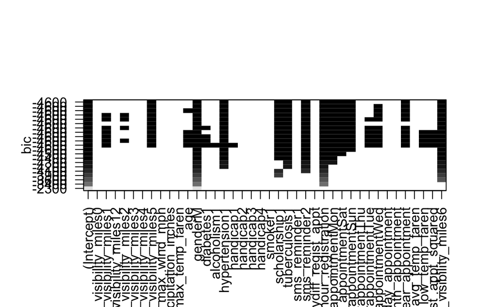

```r
plot(fit)
```

Important variables (by decreasing order):  
- age  
- daydiff_regist_appt  
- daydiff_regist_appt_squared  
- hour_registration  
- smoker1  
- scholarship1  
- alcoholism1  
- sms_reminder1  
- appointment_Mon  
- appointment_Sat  
Those was the one having the more impact in the Exploratory Data Analysis. Those results aren’t a surprise.

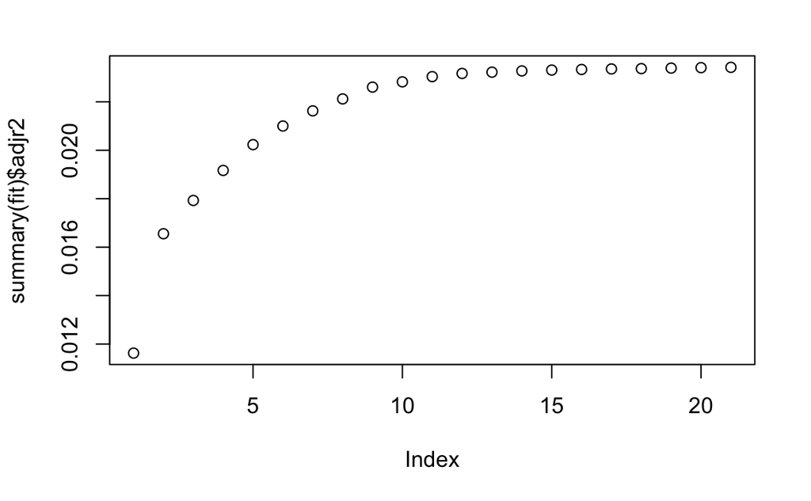

```r
plot(summary(fit)$adjr2)
```

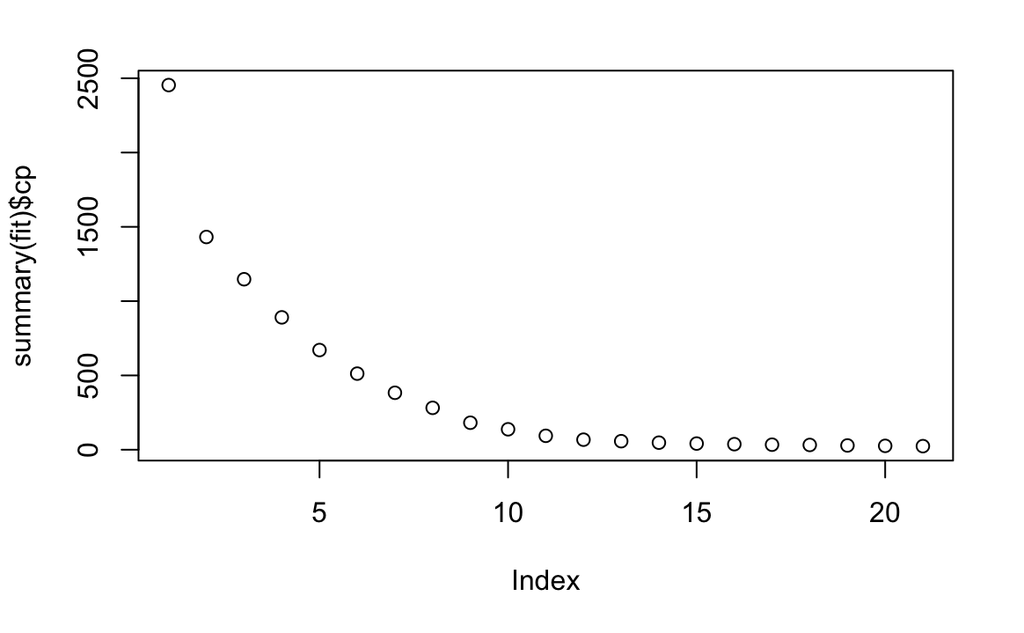

```r
plot(summary(fit)$cp)
```

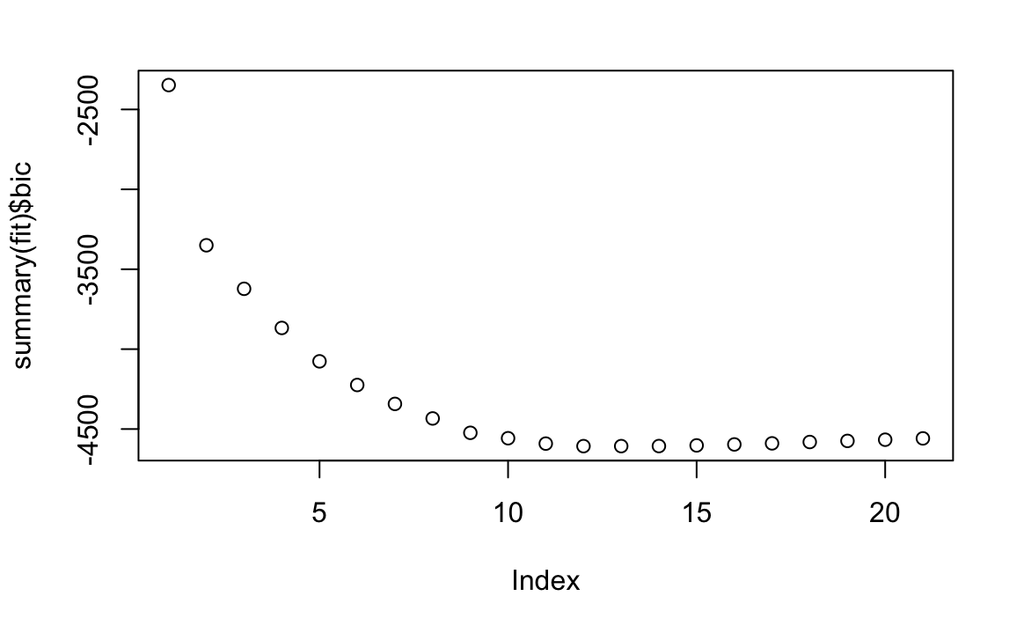

```r
plot(summary(fit)$bic)
```

However, this analysis straighten some of our previous points: age, daydiff_regist_appt and hour_registration are important features that explain a lot the show/noshow ratio.

Let us now focus on the predictive model. Apparently, after this preliminary analysis, linear correlation don’t explain enough to use it as a predictive model. Thus, let us focus on tree-based algorithm.

**Tree-base method**

```r
fit.tree = randomForest(show_up~.,
                        data = df.train.sub,
                        importance=TRUE,
                        mtry = 2,
                        ntree=100)
fit.tree
```

```
Call:
 randomForest(formula = show_up ~ ., data = df.train.sub, importance = TRUE,      mtry = 2, ntree = 100)
               Type of random forest: classification
                     Number of trees: 100
No. of variables tried at each split: 2

        OOB estimate of  error rate: 29.87%
Confusion matrix:
     0      1 class.error
0 2274  59172 0.962991895
1 1390 139933 0.009835625
```

```r
importance(fit.tree)[,4]
```

```
    lowest_visibility_miles                max_wind_mph
                   856.1031                   1391.7032
       precipitation_inches              max_temp_faren
                   543.5822                   1412.7771
                        age                      gender
                  4069.2231                    555.4608
                   diabetes                  alcoholism
                   265.8140                    204.0734
               hypertension                    handicap
                   424.7618                    221.8905
                     smoker                 scholarship
                   294.8856                    350.6842
               tuberculosis                sms_reminder
                    12.8938                    520.9677
        daydiff_regist_appt           hour_registration
                  2330.6277                   2435.0115
        weekday_appointment             day_appointment
                  1129.1769                   1661.6970
          month_appointment     day_of_year_appointment
                  1083.3643                   1867.3170
             avg_temp_faren              low_temp_faren
                  1228.9289                   1346.4404
daydiff_regist_appt_squared
                  2405.5060
```

The more important variables are the same as the on highlighted above:  
- Age  
- Hour of registration  
- The number of days between the registration adn the appointment

```r
rf.pred <- predict(fit.tree,
                   df.train.sub,
                   type="class")
table(rf.pred, df.train$show_up)
```

```
rf.pred      0      1
      0   7490    336
      1  53956 140987
```

```r
1-mean(rf.pred==df.train$show_up)
```

```
[1] 0.267753
```

```r
rf.fit <- randomForest(show_up~.,
                        data = df.train.sub,
                        importance=TRUE,
                        mtry = 2,
                        ntree=1000)
```

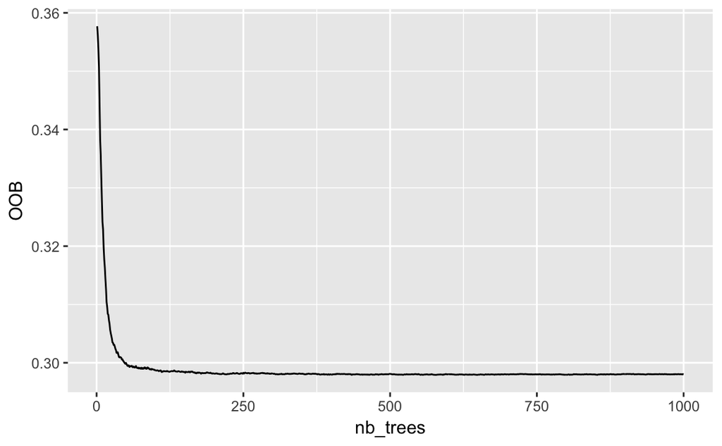

```r
err <- rf.fit$err.rate[,]
nb_trees <- seq(1:1000)
err <- as.data.frame(cbind(err, nb_trees))
ggplot(err, aes(x=nb_trees, y=OOB)) +
  geom_line()
```

The out-of-bag error is a good approximation of the out of sample event. It allows us to not use cross-validation which necessites a huge computation power.  
We see that augmenting the number of trees isn’t helping much. The out-of-bag error is bounded to ~29%.

**Boosting** Doesn’t work

```r
boost.fit <- gbm(show_up~.,
                 data=df.train.sub,
                 distribution="bernoulli",
                 n.trees=100,
                 interaction.depth=1,
                 shrinkage=0.01)
```

```r
boost.fit
```

```
gbm(formula = show_up ~ ., distribution = "bernoulli", data = df.train.sub,
    n.trees = 100, interaction.depth = 1, shrinkage = 0.01)
A gradient boosted model with bernoulli loss function.
100 iterations were performed.
There were 23 predictors of which 0 had non-zero influence.
```

```r
summary(boost.fit)
```

[output not shown]